# Fitness summary

SYSTEM: R version 4.3.3 (2024-02-29)

DATE: 2024-09-13 12:53:06.897605

# 1 Requirements

- loading libraries `dplyr`, `ggplot2`, `tidyr`

# 2 Sample overview

## 2.1 Data import

- Checking if result file(s) are available:

| input_files | size | isdir | mode | mtime | uname |
| --- | --- | --- | --- | --- | --- |
| result.Rdata | 7.459548 MB | FALSE | 664 | 2024-09-13 12:52:06.556158 | ute |

- Importing result tables:

```
[1] "Import of fitness table complete."
```

## 2.2 Conditions table

| condition | time | barcodes | DESeq_baseMean | DESeq_log2FC |
| --- | --- | --- | --- | --- |
| CO2_30percent | 0 | 21470 | NaN | 0.0000000 |
| CO2_30percent | 4 | 21470 | 130.8741 | -0.1517941 |
| CO2_30percent | 8 | 21470 | 130.8741 | -0.2830332 |
| CO2_30percent | 10 | 21470 | 130.8741 | -0.3314716 |
| CO2_4percent | 0 | 21470 | NaN | 0.0000000 |
| CO2_4percent | 4 | 21470 | 130.8741 | -0.1674894 |
| CO2_4percent | 8 | 21470 | 130.8741 | -0.3668629 |
| CO2_4percent | 10 | 21470 | 130.8741 | -0.4517467 |

# 3 Fitness scores

## 3.1 Barcode correlation

- Plots show the *correlation* of log2 FC over time for each barcode in relation to other barcodes for the same gene
- correlation is broken down by position/index of the barcode
- this representation can reveal if certain positions (i.e. distant from TSS) are biased

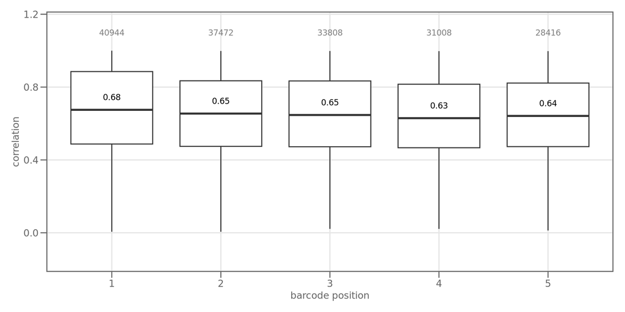

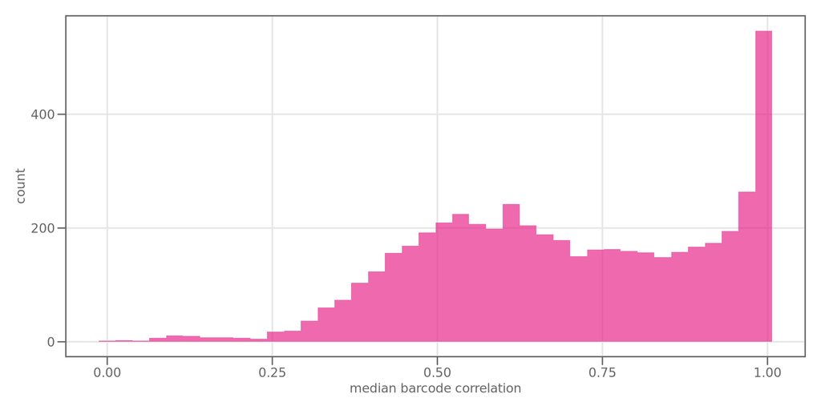

## 3.2 Barcode efficiency

- Plots show the *efficiency* for each barcode in relation to other barcodes for the same gene
- efficiency here means the ability of a mutant to cause an effect
- correlation is broken down by position/index of the barcode
- this representation can reveal if certain positions (i.e. distant from TSS) are less effective in causing a fitness effect
- indices/positions with less than 3% of all barcodes are removed

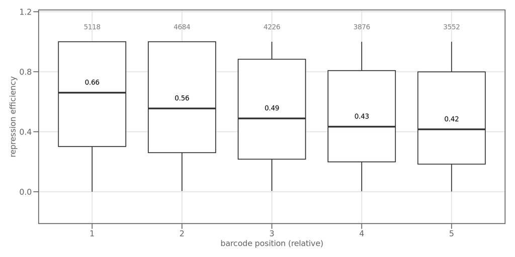

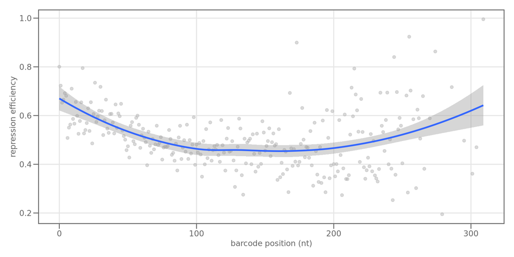

## 3.3 Barcode fitness

- This plot shows the global distribution of *barcode fitness score*
- Metric is the fitness of each barcode (mutant/sgRNA/…) in each condition
- Fitness is defined as the area under curve of log2 FC over time, normalized by time
- A *positive* fitness score means enrichment of the respective barcode, *negative* fitness means depletion
- This information is useful to show global differences between conditions, e.g. stronger vs weaker selection

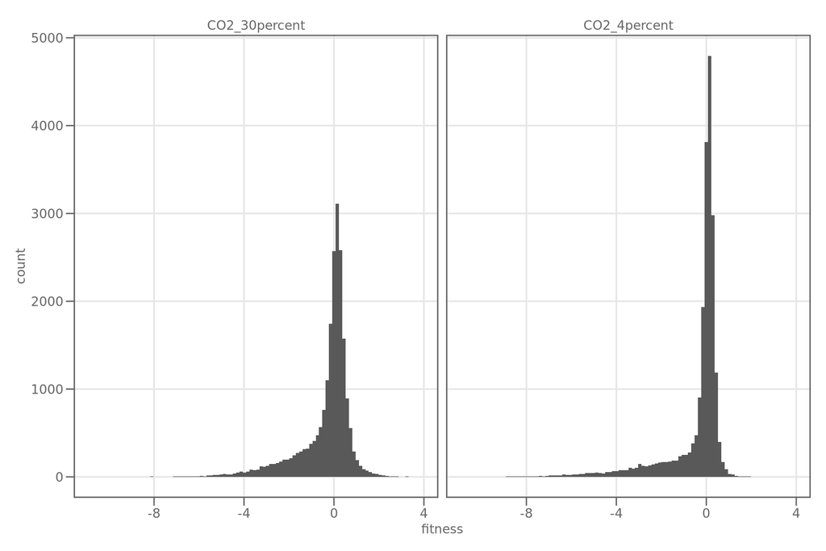

## 3.4 Gene fitness

- This plot shows the global distribution of gene fitness
- Metric is the weighted mean fitness of all barcodes
- This information is useful to show global differences between conditions, e.g. stronger vs weaker selection

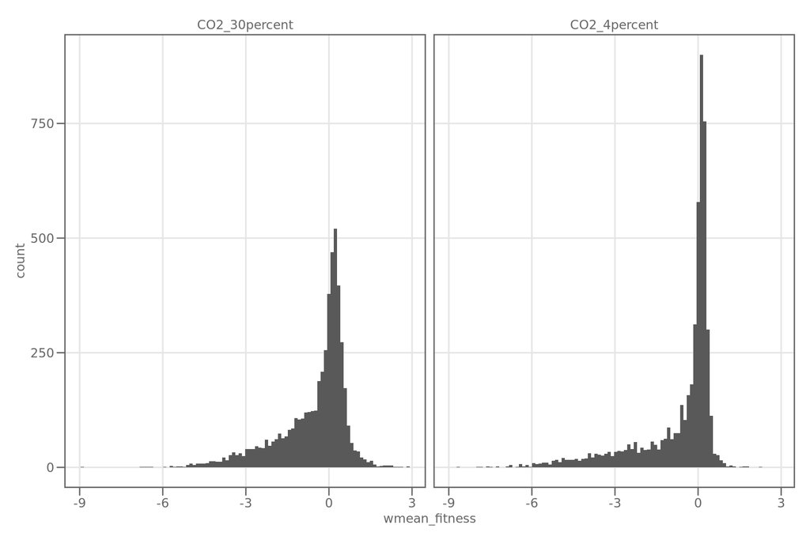

- This plot shows the global distribution of effect size versus significance score
- Effect size is the weighted mean fitness of all barcodes
- Significance is the adjusted p-value from 2-sided Wilcoxon rank sum test
- This plot is useful to judge how many genes are *significantly* enriched or depleted

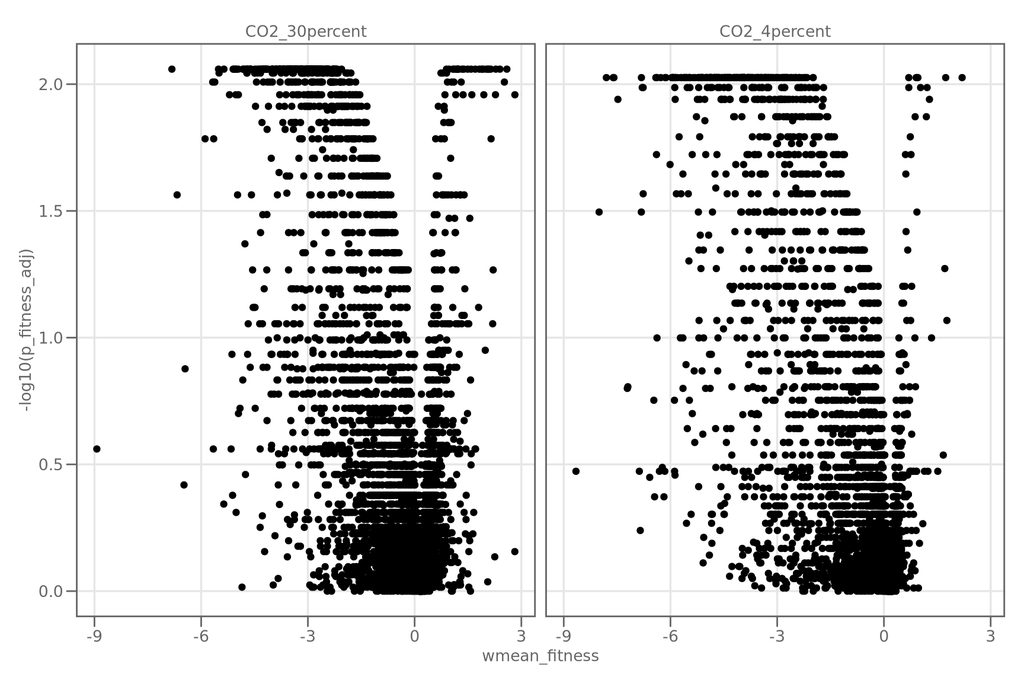

# 4 Report info

The template for this report is located in `./nf-core-crispriscreen/bin/fitness_summary.Rmd`.

Date: 2022-04-28

Author: Michael Jahn, PhD

Affilations:

- Science For Life Laboratory (KTH), Stockholm, Sweden
- Max-Planck-Unit for the Science of Pathogens, Berlin, Germany